# PSTAT 131-HW3

2022-10-30

```r
library(tidymodels)
library(ISLR) # For the Smarket data set
library(ISLR2) # For the Bikeshare data set
library(discrim)
library(poissonreg)
library(corrr)
library(klaR) # for naive bayes
tidymodels_prefer()
titanic_data <- read.csv('data/titanic.csv')
```

```r
set.seed(222)

titanic_data$pclass <- factor(titanic_data$pclass)
titanic_data$survived <- factor(titanic_data$survived, levels = c("Yes", "No"))
```

## Question 1

```r
titanic_split <- initial_split(titanic_data, prop = 0.7, strata = survived)
titanic_train <- training(titanic_split)
titanic_test <- testing(titanic_split)
view(titanic_train)
```

There are missing values within variables such as age and cabin; therefore it is also a good idea to stratify the data so we can get a more precise analysis of the entire data set

## Question 2

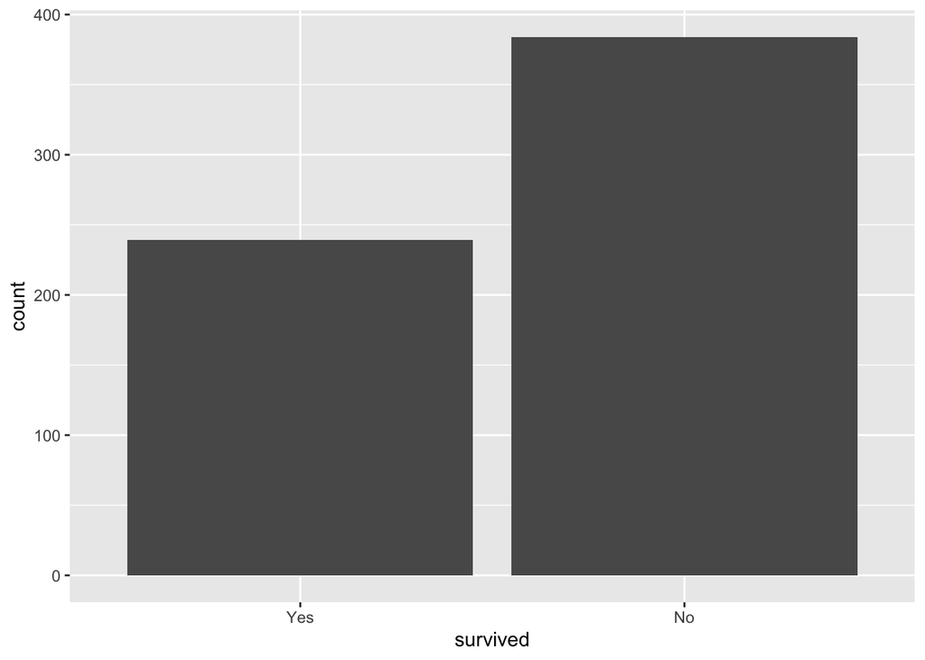

```r
titanic_train %>%
  ggplot(aes(survived)) +
  geom_bar()
```

According to the bar graph, we can see that there are more passengers than did not survive than did survive. Roughly, I would say that, in the training set, “No” accounts for about 3/5 of the data and “Yes” takes about 2/5.

## Question 3

```r
cor_titanic <- titanic_train %>%
  select(age, fare, passenger_id, parch, sib_sp) %>%
  correlate()
```

```
## Correlation computed with
## • Method: 'pearson'
## • Missing treated using: 'pairwise.complete.obs'
```

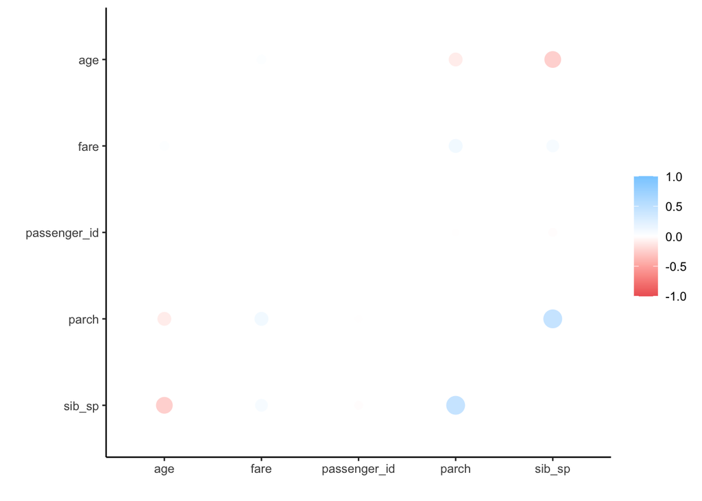

```r
rplot(cor_titanic)
```

After observing this correlation matrix, I do no see any obvious patterns, but we do see correlations between sib_sp & age (negative), sib_sp & parch (positive), parch & age (negative), parch & sib_sp (positive), and fare & parch (positive)

## Question 4

```r
titanic_recipe <- recipe(survived ~ pclass + sex + age + sib_sp + parch + fare, data = titanic_train) %>%
  step_impute_linear(age) %>%
  step_dummy(all_nominal_predictors()) %>%
  step_interact(terms = ~ starts_with("sex"):fare) %>%
  step_interact(terms = ~ age:fare)
```

## Question 5

```r
titanic_reg <- logistic_reg() %>%
  set_engine("glm") %>%
  set_mode("classification")

titanic_lin_wkflow <- workflow() %>%
  add_model(titanic_reg) %>%
  add_recipe(titanic_recipe)

titanic_lin_fit <- fit(titanic_lin_wkflow, titanic_train)
```

## Question 6

```r
titanic_lda <- discrim_linear() %>%
  set_mode("classification") %>%
  set_engine("MASS")

titanic_lda_wkflow <- workflow() %>%
  add_model(titanic_lda) %>%
  add_recipe(titanic_recipe)

titanic_lda_fit <- fit(titanic_lda_wkflow, titanic_train)
```

## Question 7

```r
titanic_qda <- discrim_quad() %>%
  set_mode("classification") %>%
  set_engine("MASS")

titanic_qda_wkflow <- workflow() %>%
  add_model(titanic_qda) %>%
  add_recipe(titanic_recipe)

titanic_qda_fit <- fit(titanic_qda_wkflow, titanic_train)
```

## Question 8

```r
titanic_nb <- naive_Bayes() %>%
  set_mode("classification") %>%
  set_engine("klaR") %>%
  set_args(usekernel = FALSE)

titanic_nb_wkflow <- workflow() %>%
  add_model(titanic_nb) %>%
  add_recipe(titanic_recipe)

titanic_nb_fit <- fit(titanic_nb_wkflow, titanic_train)
```

## Question 9

```r
lin_pred <- predict(titanic_lin_fit, new_data = titanic_train)
lda_pred <- predict(titanic_lda_fit, new_data = titanic_train)
qda_pred <- predict(titanic_qda_fit, new_data = titanic_train)
nb_pred <- predict(titanic_nb_fit, new_data = titanic_train)

bind_cols(lin_pred, lda_pred, qda_pred, nb_pred)
```

```
## # A tibble: 623 × 4
##    .pred_class...1 .pred_class...2 .pred_class...3 .pred_class...4
##    <fct>           <fct>           <fct>           <fct>
##  1 No              No              No              No
##  2 No              No              No              No
##  3 No              No              No              No
##  4 No              No              Yes             No
##  5 Yes             Yes             Yes             Yes
##  6 Yes             Yes             No              No
##  7 No              No              Yes             Yes
##  8 No              No              No              No
##  9 No              No              No              No
## 10 No              No              No              No
## # … with 613 more rows
## # ℹ Use `print(n = ...)` to see more rows
```

```r
lin_acc <- augment(titanic_lin_fit, new_data = titanic_train) %>%
  accuracy(truth = survived, estimate = .pred_class)
# 0.787
lda_acc <- augment(titanic_lda_fit, new_data = titanic_train) %>%
  accuracy(truth = survived, estimate = .pred_class)
# 0.780
qda_acc <- augment(titanic_qda_fit, new_data = titanic_train) %>%
  accuracy(truth = survived, estimate = .pred_class)
# 0.759
nb_acc <- augment(titanic_nb_fit, new_data = titanic_train) %>%
  accuracy(truth = survived, estimate = .pred_class)
# 0.756
```

The logistic regression model did the best – having a 78.7% accuracy

## Question 10

```r
predict(titanic_lin_fit, new_data = titanic_test, type = "prob")
```

```
## # A tibble: 268 × 2
##    .pred_Yes .pred_No
##        <dbl>    <dbl>
##  1    0.113     0.887
##  2    0.0910    0.909
##  3    0.315     0.685
##  4    0.852     0.148
##  5    0.766     0.234
##  6    0.802     0.198
##  7    0.0770    0.923
##  8    0.488     0.512
##  9    0.212     0.788
## 10    0.124     0.876
## # … with 258 more rows
## # ℹ Use `print(n = ...)` to see more rows
```

```r
augment(titanic_lin_fit, new_data = titanic_test) %>%
  conf_mat(truth = survived, estimate = .pred_class)
```

```
##           Truth
## Prediction Yes  No
##        Yes  78  15
##        No   25 150
```

```r
augment(titanic_lin_fit, new_data = titanic_test) %>%
  accuracy(truth = survived, estimate = .pred_class)
```

```
## # A tibble: 1 × 3
##   .metric  .estimator .estimate
##   <chr>    <chr>          <dbl>
## 1 accuracy binary         0.851
```

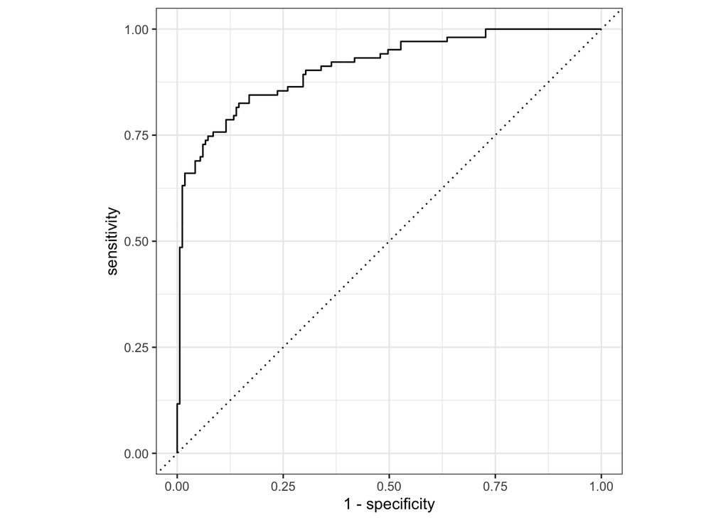

```r
augment(titanic_lin_fit, new_data = titanic_test) %>%
  roc_curve(survived, .pred_Yes) %>%
  autoplot()
```

```r
augment(titanic_lin_fit, new_data = titanic_test) %>%
  roc_auc(survived, .pred_Yes)
```

```
## # A tibble: 1 × 3
##   .metric .estimator .estimate
##   <chr>   <chr>          <dbl>
## 1 roc_auc binary         0.910
```

When I used my testing data, I was able to obtain an AUC of 0.910. This did relatively better than my training accuracy, which topped out at about 78. This might be due to the fact that the data was split 70/30, and being that there is only a limited amount of passengers on the Titanic, this difference could have been simply by chance.